# Cortisol Dataset Analysis

In this problem, we consider a blind study where all the pigs are randomly assigned with a certain diet with or without chips, and we are interested in the effect of chips (so the covariate `group`) on urine cortisol. As the causal influence among hormones remains unknown, we only consider `urine cortisol` as the response variable in our analysis. We first import and clean the data as follows:

```r
# Import data
cortisol_data = read.csv("data/cortisol.csv", row.names=1)

# Create data frame
dat = data.frame(group = cortisol_data$group,
                 gender = cortisol_data$gender,
                 urine_cortisol = cortisol_data$Urine.Cortisol..pg.mg.,
                 serum_cortisol = cortisol_data$Serum.Cortisol..ng.ml.,
                 ACTH = cortisol_data$Serum.ACTH..pg.ml.,
                 CRH = cortisol_data$Serum.CRH..pg.ml.,
                 testosterone = cortisol_data$Testosterone..ng.ml.,
                 LH = cortisol_data$LH..ng.ml.)

head(dat[,1:3])
```

```
##   group gender urine_cortisol
## 1     C   male      1509.7096
## 2    NC female       698.5621
## 3    NC female       187.7233
## 4     C   male       736.5923
## 5    NC female       542.4715
## 6     C female      1872.2579
```

# Simple analysis

We start our analysis by visualizing the data to grasp an idea of how the data is like.

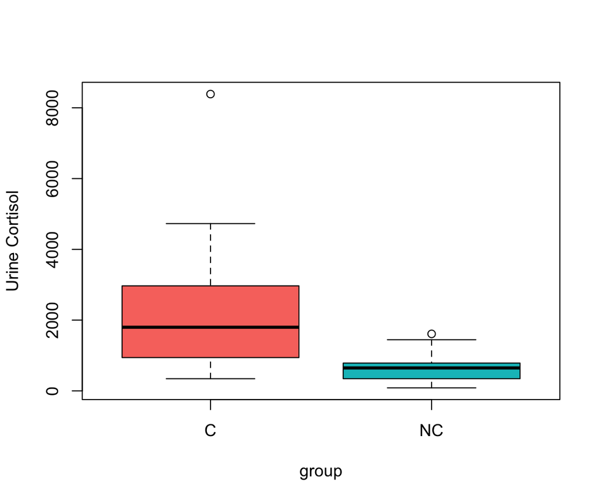

```r
gg_color_hue = function(n, alpha = 1) {
  hues = seq(15, 375, length = n + 1)
  hcl(h = hues, l = 65, c = 100, alpha = alpha)[1:n]
}

cols = gg_color_hue(2)
cols_trans = gg_color_hue(2, alpha = 0.15)

boxplot(urine_cortisol ~ group, data = dat, col = cols, ylab = "Urine Cortisol")
```

As we can see, the groups of `Chips` and `Non-chips` show different mean, different variance with some outliers. Therefore, it is not suitable to be analyzed by any of the methods we have discussed so far. Let’s try a log transformation on the response variable and see if we can get something better.

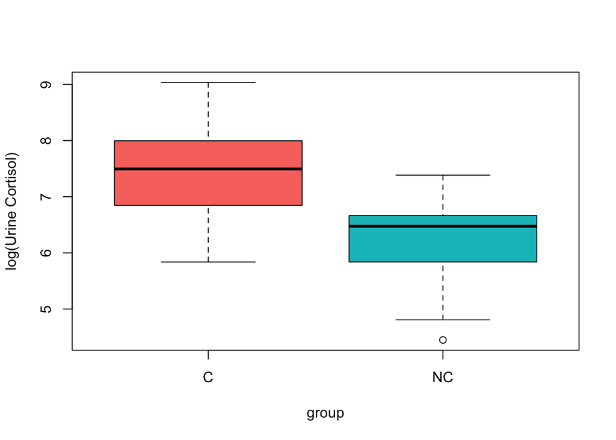

```r
boxplot(log(urine_cortisol) ~ group, data = dat, col = cols, ylab = "log(Urine Cortisol)")
```

```r
t.test(log(urine_cortisol) ~ group, data = dat, col = cols, alternative = "greater")
```

```
##
##  Welch Two Sample t-test
##
## data:  log(urine_cortisol) by group
## t = 6.1625, df = 50.799, p-value = 5.782e-08
## alternative hypothesis: true difference in means is greater than 0
## 95 percent confidence interval:
##  0.9003832       Inf
## sample estimates:
##  mean in group C mean in group NC
##         7.448626         6.212052
```

Since the p-value is smaller than 5%, we can conclude that the chips diet significantly increases the level of urine cortisol **on the log scale**, at the significance level of 5%. However, what can we say on the original scale of urine cortisol? This will need to involve a more complicated study with the Generalized Linear Models (GLM).

# More complex analysis with GLM

Consider the following model where we assume that the level of urine cortisol ($Y_i$) follows a gamma distribution

$$Y_i \sim \text{Gamma}(\mu_i, \sigma),$$

where $\mu_i$, the conditional mean of $Y_i$, is modelled by

$$\mu_i = \exp(\mathbf{x}_i^T \boldsymbol{\beta}),$$
and $\sigma$ is related to the conditional variance of $Y_i$ as $\text{var}(Y_i) = \mu_i^2 \sigma^2$. You can check out more details about the reparametrization of gamma distribution we use by loading the `gamlss` R package and checking the documentation of the `GA` function.

```r
library(gamlss)
```

Now let’s try to fit the considered model with the `gamlss` function.

```r
fit_ga_urine_cortisol = gamlss(urine_cortisol ~ group, data = dat,
                               sigma.formula =~ 1, family = GA)
```

```
## GAMLSS-RS iteration 1: Global Deviance = 956.7006
## GAMLSS-RS iteration 2: Global Deviance = 956.7006
```

```r
summary(fit_ga_urine_cortisol)
```

```
## Family:  c("GA", "Gamma")
##
## Call:  gamlss(formula = urine_cortisol ~ group, sigma.formula = ~1,
##     family = GA, data = dat)
##
## Fitting method: RS()
##
## ------------------------------------------------------------------
## Mu link function:  log
## Mu Coefficients:
##             Estimate Std. Error t value Pr(>|t|)
## (Intercept)   7.7315     0.1326  58.312  < 2e-16 ***
## groupNC      -1.3016     0.1750  -7.436 5.43e-10 ***
## ---
## Signif. codes:  0 '***' 0.001 '**' 0.01 '*' 0.05 '.' 0.1 ' ' 1
##
## ------------------------------------------------------------------
## Sigma link function:  log
## Sigma Coefficients:
##             Estimate Std. Error t value Pr(>|t|)
## (Intercept) -0.39145    0.08454   -4.63 2.11e-05 ***
## ---
## Signif. codes:  0 '***' 0.001 '**' 0.01 '*' 0.05 '.' 0.1 ' ' 1
##
## ------------------------------------------------------------------
## No. of observations in the fit:  61
## Degrees of Freedom for the fit:  3
##       Residual Deg. of Freedom:  58
##                       at cycle:  2
##
## Global Deviance:     956.7006
##             AIC:     962.7006
##             SBC:     969.0333
```

Before we draw any conlusion from the fitted model, we should first check if the model is suitable given the data. It is possible to compute standardized residuals as follows:

$$r_i = \frac{Y_i - \widehat{\mu}_i}{\widehat{\sigma}_i},$$
where $\widehat{\mu}_i$ and $\widehat{\sigma}_i$ correspond to the predicted (by the estimated model) mean and standard deviation for observation $i$. Therefore, we can perform the following model check:

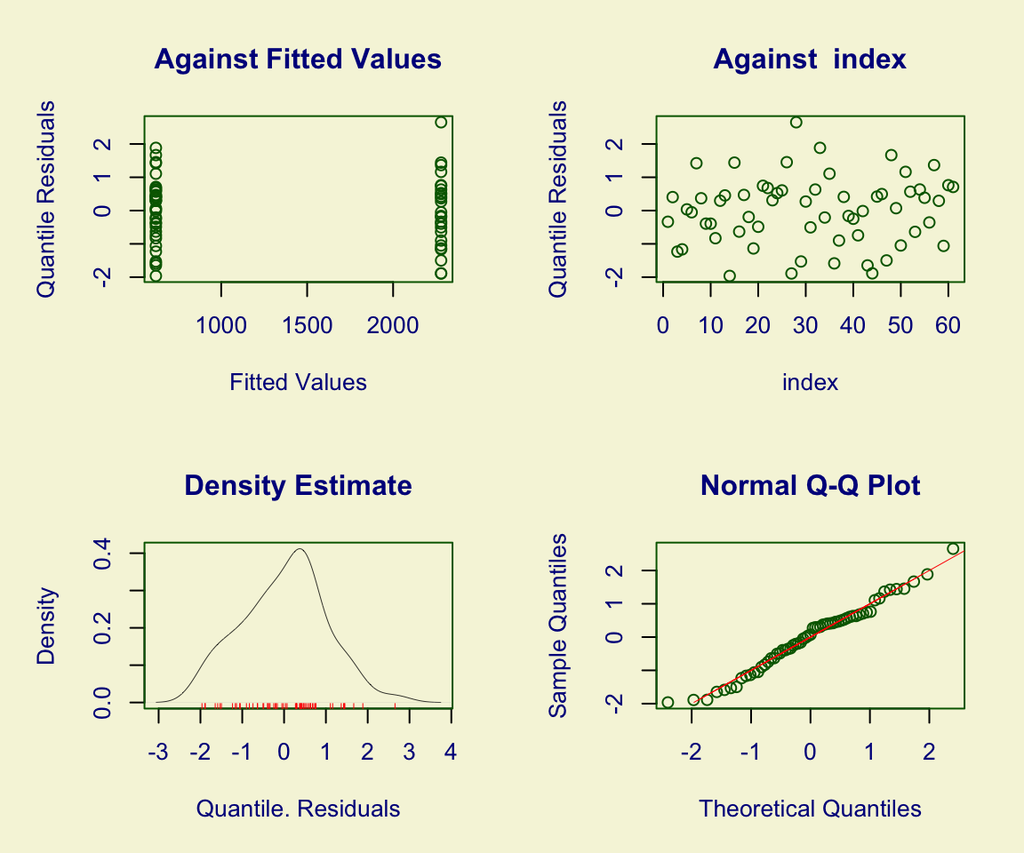

```
##        Summary of the Quantile Residuals
##                            mean   =  -0.0005430463
##                        variance   =  1.016182
##                coef. of skewness  =  0.02265806
##                coef. of kurtosis  =  2.640994
## Filliben correlation coefficient  =  0.9919967
```

```r
plot(fit_ga_urine_cortisol)
```

We can also obtain the following fitted densities as follows:

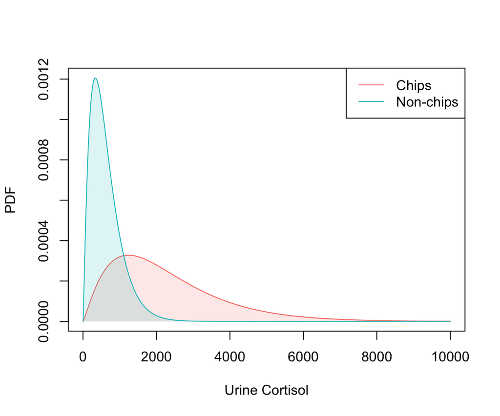

```r
mu_coef = fit_ga_urine_cortisol$mu.coefficients
sigma_coef = fit_ga_urine_cortisol$sigma.coefficients

mu_chips = mu_coef["(Intercept)"]
mu_non_chips = mu_coef["(Intercept)"] + mu_coef["groupNC"]

xx = seq(from = 0.0001, to = 10^4, length.out = 10^4)
yy_chips = dGA(xx, mu = exp(mu_chips), sigma = exp(sigma_coef))
yy_non_chips = dGA(xx, mu = exp(mu_non_chips), sigma = exp(sigma_coef))

plot(NA, xlim = c(0, 10^4), ylim = c(0, max(na.omit(yy_non_chips))), xlab = "Urine Cortisol", ylab = "PDF")

polygon(c(xx, rev(xx)), c(rep(0, length(xx)), rev(yy_chips)), border = NA, col = cols_trans[1])
lines(xx, yy_chips, col = cols[1], lwd = 1)

polygon(c(xx, rev(xx)), c(rep(0, length(xx)), rev(yy_non_chips)), border = NA, col = cols_trans[2])
lines(xx, yy_non_chips, col = cols[2], lwd = 1)

legend("topright", c("Chips", "Non-chips"), col = cols, lwd = 1)
```

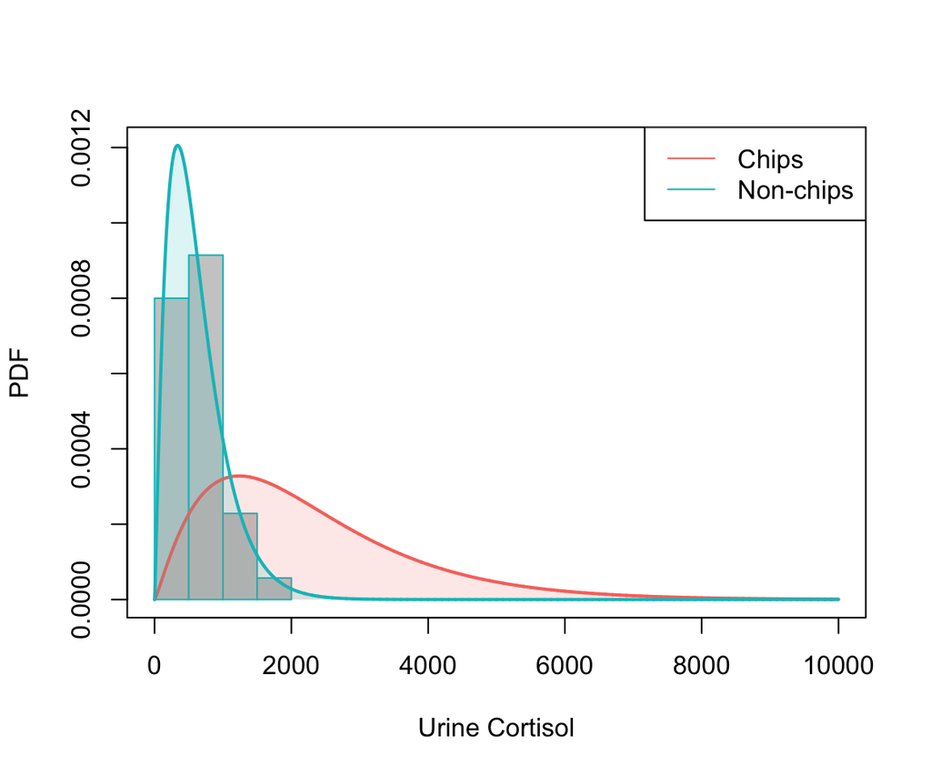

```r
plot(NA, xlim = c(0, 10^4), ylim = c(0, max(na.omit(yy_non_chips))), xlab = "Urine Cortisol", ylab = "PDF")

hist(dat$urine_cortisol[dat$group == "NC"], probability = TRUE, add = TRUE, col = "grey80", breaks = 3, border = cols[2])

polygon(c(xx, rev(xx)), c(rep(0, length(xx)), rev(yy_chips)), border = NA, col = cols_trans[1])
lines(xx, yy_chips, col = cols[1], lwd = 2)

polygon(c(xx, rev(xx)), c(rep(0, length(xx)), rev(yy_non_chips)), border = NA, col = cols_trans[2])
lines(xx, yy_non_chips, col = cols[2], lwd = 2)

legend("topright", c("Chips", "Non-chips"), col = cols, lwd = 1)
```

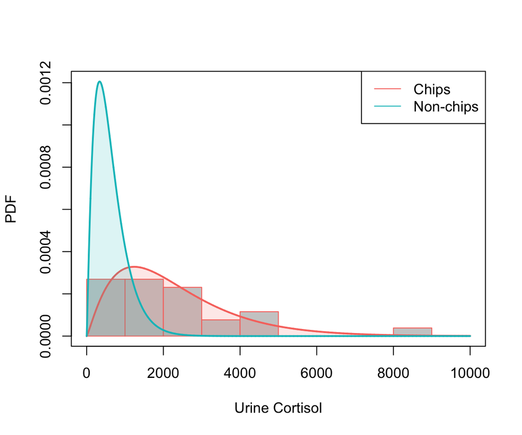

```r
plot(NA, xlim = c(0, 10^4), ylim = c(0, max(na.omit(yy_non_chips))), xlab = "Urine Cortisol", ylab = "PDF")

hist(dat$urine_cortisol[dat$group == "C"], probability = TRUE, add = TRUE, col = "grey80", breaks = 10, border = cols[1])

polygon(c(xx, rev(xx)), c(rep(0, length(xx)), rev(yy_chips)), border = NA, col = cols_trans[1])
lines(xx, yy_chips, col = cols[1], lwd = 2)

polygon(c(xx, rev(xx)), c(rep(0, length(xx)), rev(yy_non_chips)), border = NA, col = cols_trans[2])
lines(xx, yy_non_chips, col = cols[2], lwd = 2)

legend("topright", c("Chips", "Non-chips"), col = cols, lwd = 1)
```

The above graphs show that the model fits the data very well. Therefore, it is reliable to draw conclusion based on this fitted gamma GLM. Since the p-value related to the `groupNC` covariate is $5.43 \times 10^{-8}\%$, and that the estimated coefficient is $-1.3016$, the p-value that corresponds to the hypotheses $H_0: \mu_{C} = \mu_{NC}$ and $H_a: \mu_{C} > \mu_{NC}$ is therefore $5.43 \times 10^{-8}\%/2 \approx 2.72\times 10^{-8}\%$. So we can conclude that the chips diet significantly increases the level of urine cortisol at the significance level of 5%.

# Supplementary analysis: Gender

As the experiment is a blind study, we expect not to see significant difference between different genders. To verify our expectation, let’s fit the model again by adding the covariate `gender`.

```r
fit_ga_urine_cortisol2 = gamlss(urine_cortisol ~ group*gender, data = dat, sigma.formula =~ 1, family = GA)
```

```
## GAMLSS-RS iteration 1: Global Deviance = 956.3047
## GAMLSS-RS iteration 2: Global Deviance = 956.3047
```

```r
summary(fit_ga_urine_cortisol2)
```

```
## Family:  c("GA", "Gamma")
##
## Call:  gamlss(formula = urine_cortisol ~ group * gender, sigma.formula = ~1,
##     family = GA, data = dat)
##
## Fitting method: RS()
##
## ------------------------------------------------------------------
## Mu link function:  log
## Mu Coefficients:
##                    Estimate Std. Error t value Pr(>|t|)
## (Intercept)         7.77418    0.18018  43.147  < 2e-16 ***
## groupNC            -1.41874    0.25481  -5.568 7.59e-07 ***
## gendermale         -0.09483    0.26522  -0.358    0.722
## groupNC:gendermale  0.21614    0.35277   0.613    0.543
## ---
## Signif. codes:  0 '***' 0.001 '**' 0.01 '*' 0.05 '.' 0.1 ' ' 1
##
## ------------------------------------------------------------------
## Sigma link function:  log
## Sigma Coefficients:
##             Estimate Std. Error t value Pr(>|t|)
## (Intercept) -0.39428    0.08457  -4.662 1.98e-05 ***
## ---
## Signif. codes:  0 '***' 0.001 '**' 0.01 '*' 0.05 '.' 0.1 ' ' 1
##
## ------------------------------------------------------------------
## No. of observations in the fit:  61
## Degrees of Freedom for the fit:  5
##       Residual Deg. of Freedom:  56
##                       at cycle:  2
##
## Global Deviance:     956.3047
##             AIC:     966.3047
##             SBC:     976.859
```

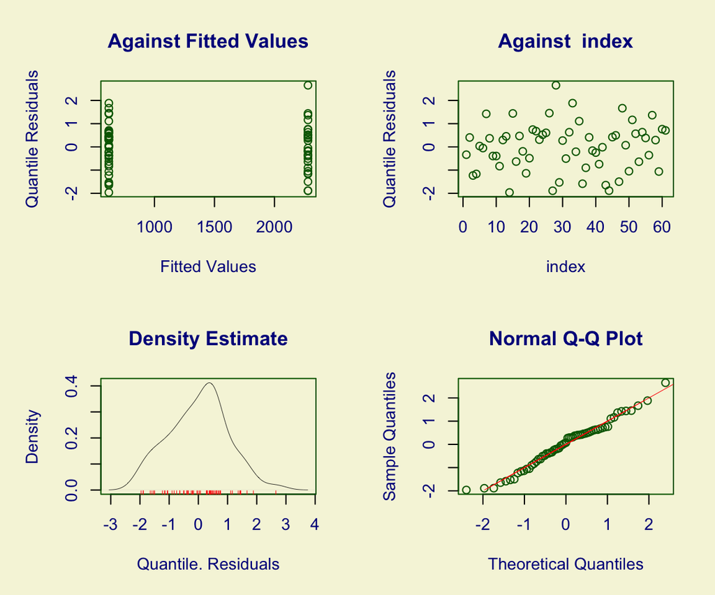

```
##        Summary of the Quantile Residuals
##                            mean   =  -0.0005430463
##                        variance   =  1.016182
##                coef. of skewness  =  0.02265806
##                coef. of kurtosis  =  2.640994
## Filliben correlation coefficient  =  0.9919967
```

```r
plot(fit_ga_urine_cortisol)
```

As we can see, the considered model fits well the data, and the covariates related to `gender` are both not significant, which verifies our expectation and concludes the analysis.